# 2.6 Arctic sea ice

### Unit 2: Climate

#### Lesson 6: Arctic sea ice

#### Skills: read data, plot, save figure, for loops, subsetting, boolean logic, install package (lubridate)

### Explore NOAA Arctic sea ice data

- Data website http://nsidc.org/data/G02135
- Raw data from ftp://sidads.colorado.edu/DATASETS/NOAA/G02135/north/daily/data/N_seaice_extent_daily_v3.0.csv

The Sea Ice Index provides a quick look at Arctic- and Antarctic-wide changes in long-term sea ice cover derived from satellite data. By reading the User Guide, we can learn that **the Sea Ice Index gives the sea ice extent (areal coverage) in units of million km^2 derived from satellite measurements**. The “Missing” data gives the extent of the area where data was not available in units of a million km^2. Let’s download, read and plot the daily sea ice extent in the Northern Hemisphere.

```r
# arctic_ice = read.csv("data/N_seaice_extent_daily_v3.0.csv", skip=2, header = FALSE, col.names = c("Year", "Month", "Day", "Extent", "Missing", "Source_Data"))
url = 'ftp://sidads.colorado.edu/DATASETS/NOAA/G02135/north/daily/data/N_seaice_extent_daily_v3.0.csv'
arctic_ice = read.delim(url, skip=2, sep=",", header=FALSE, col.names = c("Year", "Month", "Day", "Extent", "Missing", "Source_Data"))
head(arctic_ice)
##   Year Month Day Extent Missing
## 1 1978    10  26 10.231       0
## 2 1978    10  28 10.420       0
## 3 1978    10  30 10.557       0
## 4 1978    11   1 10.670       0
## 5 1978    11   3 10.777       0
## 6 1978    11   5 10.968       0
##                                                             Source_Data
## 1  ['/ecs/DP1/PM/NSIDC-0051.001/1978.10.26/nt_19781026_n07_v1.1_n.bin']
## 2  ['/ecs/DP1/PM/NSIDC-0051.001/1978.10.28/nt_19781028_n07_v1.1_n.bin']
## 3  ['/ecs/DP1/PM/NSIDC-0051.001/1978.10.30/nt_19781030_n07_v1.1_n.bin']
## 4  ['/ecs/DP1/PM/NSIDC-0051.001/1978.11.01/nt_19781101_n07_v1.1_n.bin']
## 5  ['/ecs/DP1/PM/NSIDC-0051.001/1978.11.03/nt_19781103_n07_v1.1_n.bin']
## 6  ['/ecs/DP1/PM/NSIDC-0051.001/1978.11.05/nt_19781105_n07_v1.1_n.bin']
```

Notice that unlike in previous data sets, the date information is split into three columns: year, month, day. This will make it harder to plot a time series since we can only plot one variable along the x axis. We could do the math to turn the month and day variables into decimal dates. Another, simpler, option is to take advantage of the `lubridate` package that was designed by other R users. Installing, loading and using functions from R packages can save you loads of time and dramatically increase the functionality of the R language. We will use many other packages throughout the course.

First, we need to install the lubridate package from the CRAN library. You can do this in RStudio using the top menu: `Tools -> Install packages...`. Then type the name of the package you want (lubridate) into the text box, make sure the `Install Dependencies` box is checked and click `Install`. Or you can simply do it at your command line with the function `install.packages("lubridate")`. Once installed, you need to load the package functions into your environment with the `library()` function. Now that the `lubridate` package is loaded up, we can use the function `make_date()` to transform your year, month and date into a `date` type variable. Don’t forget you can use the command `?make_date` to find out more about the function (or just search for the function in the Help tab of the lower left panel in RStudio).

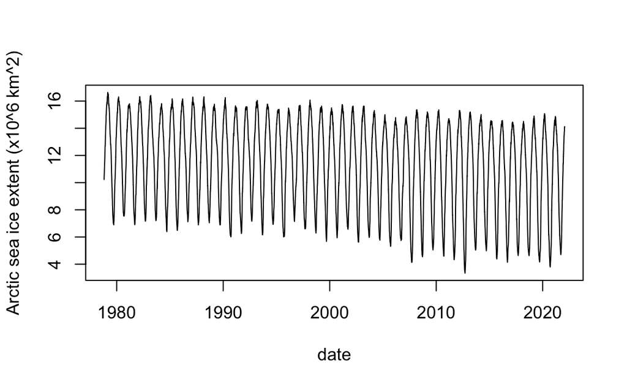

```r
# install.packages("lubridate")
library("lubridate")  # make_date()
##
## Attaching package: 'lubridate'
## The following objects are masked from 'package:base':
##
##     date, intersect, setdiff, union

arctic_ice$date = make_date(arctic_ice$Year, arctic_ice$Month, arctic_ice$Day)
plot(Extent ~ date, data=arctic_ice, ylab="Arctic sea ice extent (x10^6 km^2)", type='l')
```

Use for loops to calculate the annual average Arctic sea ice extent and the 5-year-average Arctic sea ice extent. The annual average is the mean of all of the sea ice extent observations within a given year. We’ll define the 5-year-average ice extent for some given year `x` as the mean of all sea ice exten observations within the year `x` as well as the 2 years prior and the 2 years after year `x`. For example, the 5-year-average sea ice extent for 2010 is the mean of all observations from Jan. 1 2008 to Dec. 31 2012.

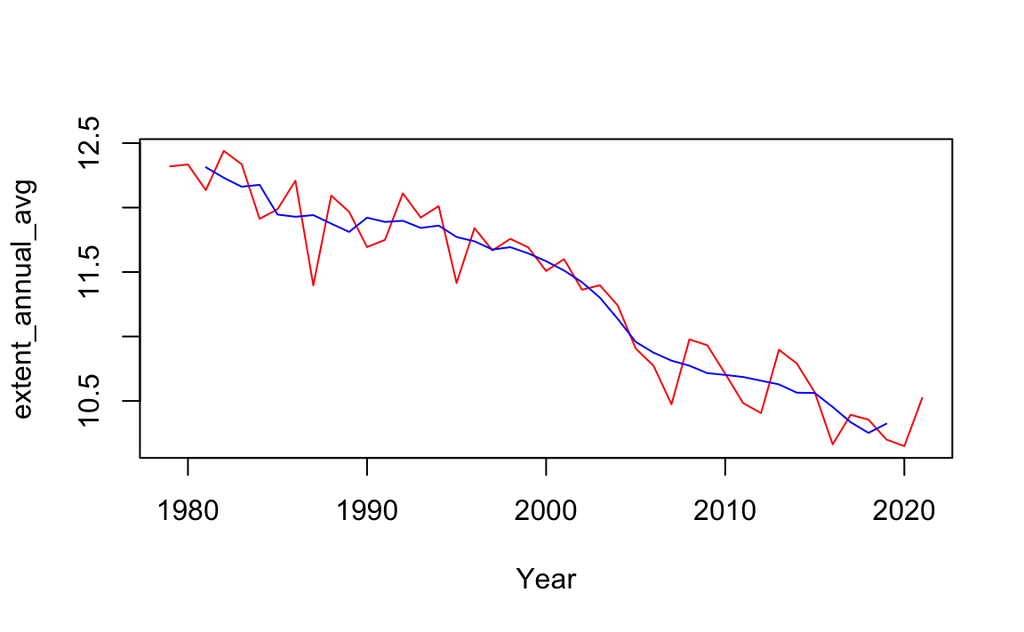

```
## integer(0)
# dev.off()
```

```r
# Dump the first year (since it's not complete!)
# Dump the most recent year (since it's not complete!)
arctic_ice_annual = data.frame(Year=seq(min(arctic_ice$Year)+1, max(arctic_ice$Year)-1), extent_annual_avg=NA, extent_5yr_avg=NA)
head(arctic_ice_annual)
##   Year extent_annual_avg extent_5yr_avg
## 1 1979                NA             NA
## 2 1980                NA             NA
## 3 1981                NA             NA
## 4 1982                NA             NA
## 5 1983                NA             NA
## 6 1984                NA             NA

# Hard-coding vs. indexing the years:
arctic_ice[which(arctic_ice$Year == 1979),'Extent'] # Find the daily data for the first year
##   [1] 14.997 14.922 14.929 14.968 15.190 15.327 15.352 15.500 15.517 15.709
##  [11] 15.679 15.745 15.686 15.777 15.912 15.857 15.839 15.831 15.801 15.990
##  [21] 16.099 16.289 16.323 16.343 16.291 16.260 16.401 16.579 16.551 16.635
##  [31] 16.457 16.568 16.547 16.536 16.513 16.414 16.310 16.467 16.505 16.349
##  [41] 16.279 16.264 16.060 15.763 15.804 15.660 15.641 15.695 15.794 15.761
##  [51] 15.655 15.500 15.454 15.510 15.343 15.255 15.224 15.141 15.108 14.961
##  [61] 14.626 14.498 14.450 14.325 14.149 14.012 13.836 13.862 13.691 13.560
##  [71] 13.529 13.364 13.399 13.292 13.260 13.076 12.977 12.832 12.791 12.854
##  [81] 12.733 12.673 12.548 12.517 12.415 12.373 12.243 12.112 11.977 11.829
##  [91] 11.562 11.363 11.255 10.936 10.793 10.662 10.503 10.401 10.256  9.927
## [101]  9.919  9.668  9.614  9.556  9.342  9.223  9.000  8.859  8.744  8.610
## [111]  8.328  8.284  8.138  7.971  7.811  7.659  7.566  7.577  7.421  7.364
## [121]  7.284  7.228  7.147  7.037  7.075  7.092  6.981  7.003  7.007  7.001
## [131]  6.910  6.895  7.033  7.058  7.127  7.173  7.404  7.534  7.813  7.878
## [141]  8.115  8.136  8.338  8.570  8.938  9.190  9.295  9.466  9.700  9.869
## [151]  9.797  9.924 10.144 10.159 10.267 10.270 10.497 10.610 10.800 10.920
## [161] 11.010 11.157 11.352 11.419 11.581 11.884 12.076 12.390 12.462 12.781
## [171] 12.991 13.101 13.292 13.268 13.322 13.377 13.541 13.619 13.773 13.934
## [181] 14.101 14.092
arctic_ice_annual$extent_annual_avg[1] = mean(arctic_ice[which(arctic_ice$Year == arctic_ice_annual$Year[1]),'Extent']) # calc and store mean extent for that first year (without hard coding year)

# calculate annual average:
for (i in seq(dim(arctic_ice_annual)[1]))
{
  arctic_ice_annual$extent_annual_avg[i] = mean(arctic_ice[which(arctic_ice$Year == arctic_ice_annual$Year[i]),'Extent'])
}

# 5-year average:
for (i in seq(3, dim(arctic_ice_annual)[1]-2)) # skip the first 2 and last 2 years
{
  years = c((arctic_ice_annual$Year[i]-2):(arctic_ice_annual$Year[i]+2))
  arctic_ice_annual$extent_5yr_avg[i] = mean(arctic_ice[which(arctic_ice$Year %in% years),'Extent'])
}

head(arctic_ice_annual)
##   Year extent_annual_avg extent_5yr_avg
## 1 1979          12.31956             NA
## 2 1980          12.33415             NA
## 3 1981          12.13549       12.31276
## 4 1982          12.43945       12.23129
## 5 1983          12.33590       12.16189
## 6 1984          11.91260       12.17647

# pdf('figures/arctic_ice_extent.pdf', width=7, height=5)
plot(extent_annual_avg ~ Year, data=arctic_ice_annual, col="red", type="l") +
  lines(extent_5yr_avg ~ Year, data=arctic_ice_annual, col="blue", type="l")
```

As you’d expect, the 5-year-average really smooths out some of that year-to-year variability and makes it a bit easier to observe the overall trend through time.

If we want to plot the annual and 5-year averages on the same plot as the original observations, we’ll have to change our `Year` variable into a `date`-type variable that will plot nicely along the dates in the original observation dataset:

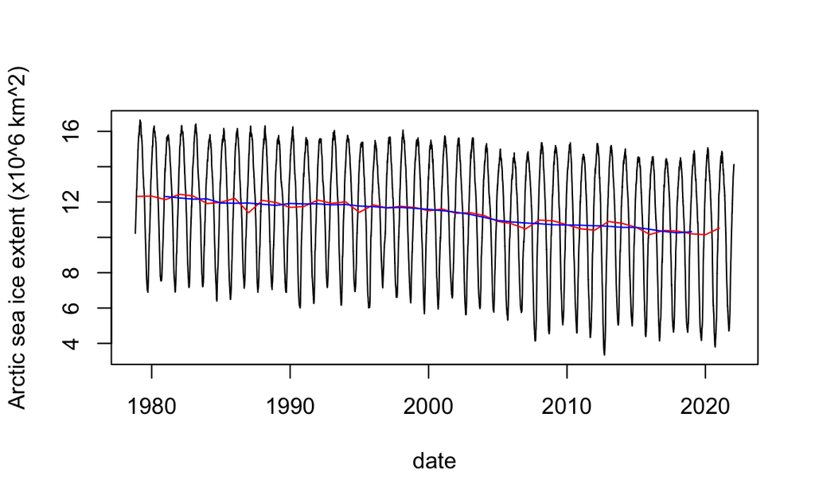

```
## integer(0)
```

```r
#To plot the annual and 5-year averages on the same plot as the original observations:
# arctic_ice_annual$date = as.Date(paste(arctic_ice_annual$Year, 1, 1, sep = "-")) # as.Date is in base R
arctic_ice_annual$date = make_date(year=arctic_ice_annual$Year) # default month and day = 1
# arctic_ice_annual$date = make_date(year=arctic_ice_annual$Year, month=7, day=1) # set to middle of year
plot(Extent ~ date, data=arctic_ice, ylab="Arctic sea ice extent (x10^6 km^2)", type='l') +
  lines(extent_annual_avg ~ date, data=arctic_ice_annual, col="red") +
  lines(extent_5yr_avg ~ date, data=arctic_ice_annual, col="blue")
```

Now, let’s calculate the observed rate of change in annually averaged ice extent across the time period by subtracting the first average Arctic ice extent area from the most recent average Arctic ice extent area, and dividing by the number of years of observation:

```r
ice_loss_million_km2 = arctic_ice_annual$extent_annual_avg[dim(arctic_ice_annual)[1]] - arctic_ice_annual$extent_annual_avg[1]
time_period = max(arctic_ice_annual$Year) - min(arctic_ice_annual$Year)

# Calc rate of ice loss:
ice_loss_million_km2_per_yr = ice_loss_million_km2 / time_period
```

### Exercise 6.1

Use a for loop to calculate the total ice loss in each full decade of the data, starting with 1980-1989. Plot the ice loss per decade in a bar plot.